```python
!jupyter nbconvert Presentation_VIZ.ipynb --to slides --post serve
```

[output not shown]

# Données de cadrage

## Objectif :

Identifier la relation entre la météo et le dynamisme d'un match, afin de cibler au mieux les dépenses publicitaires.

## Périmètre de l'étude :

- Championnat de ligue 1 2020-2021
- 20 équipes, 38 journées de rencontres pour un total de 380 matches
- Météo résumée par la pluviométrie et la température moyenne de la journée

Rappel de la commande :

- l’évolution du nombre de buts d’une équipe en fonction de la météo (pluviométrie, température)
- l’évolution du nombre de buts d’un joueur en fonction de la météo (pluviométrie, température)
- Toutes propositions permettant d’illustrer au mieux la relation entre météo et le dynamisme d’un match.

## Distribution des buts

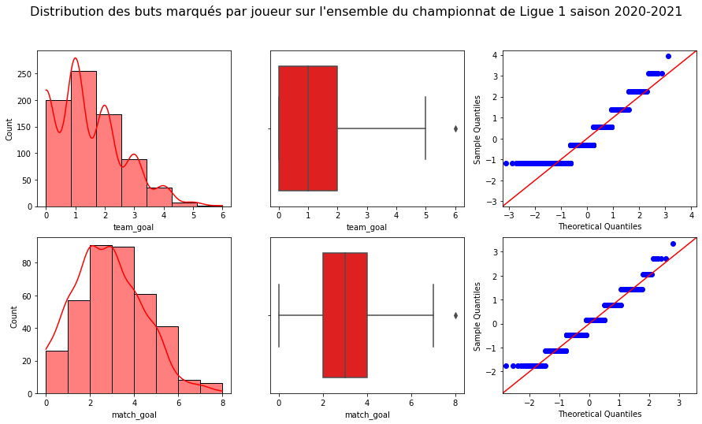

```python
df = pd.read_sql_query("SELECT match_id, team_goal FROM matches_teams;", conn)
df_2 = pd.read_sql_query("SELECT match_id, SUM(team_goal) AS match_goal FROM matches_teams GROUP BY match_id", conn)

fig, ax = plt.subplots(ncols=3,nrows = 2)
fig.set_size_inches(15, 8)

fig.suptitle("Distribution des buts marqués par joueur sur l\'ensemble du championnat de Ligue 1 saison 2020-2021", fontsize=16)
sns.histplot(data=df, x="team_goal", bins=7, kde=True, color = 'red', ax=ax[0,0])
sns.boxplot(data=df, x="team_goal", color='red', ax=ax[0,1])
sm.qqplot(df['team_goal'], stats.t, fit=True, line="45",ax=ax[0,2])


fig.suptitle('Distribution des buts marqués par joueur sur l\'ensemble du championnat de Ligue 1 saison 2020-2021', fontsize=16)
sns.histplot(data=df_2, x="match_goal", bins=8, kde=True, color = 'red',ax=ax[1,0])
sns.boxplot(data=df_2, x="match_goal", color='red',ax=ax[1,1])
sm.qqplot(df_2['match_goal'], stats.t, fit=True, line="45", ax=ax[1,2])



plt.show()
```

# Etude des relations météo - équipes

## En résumé :

- Une légère relation entre les performances des équipes et le nieau de pluie est identifiée. Etonamment, le nombre de buts tend à s'accroitre très légèrement avec la pluie. Néanmoins il est nécessaire de disposer de davantage de données pour confirmer cette tendance, qui apparaît comme très légère et non robuste.
- Présomption de relation entre les buts moyens marqués par équipe en fonction de la température. Une relation globale en cloche a été identifée (les températures extrêmes semblent défavoriser le dynamisme des matchs). Cette relation est à prendre avec précaution compte tenu du faible nombre d'observations. Si l'on s'intéresse individuellement aux performances des équipes, il est par ailleurs compliqué de dégager une tendance.

## Analyse équipes-pluviométrie :

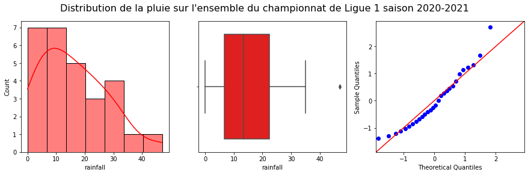

```python
df_4 = pd.read_sql_query("SELECT rainfall, COUNT(*) FROM matches GROUP BY rainfall", conn)

fig, ax = plt.subplots(ncols=3)
fig.set_size_inches(15, 4)

fig.suptitle('Distribution de la pluie sur l\'ensemble du championnat de Ligue 1 saison 2020-2021', fontsize=16)
sns.histplot(data=df_4, x="rainfall", bins=7, kde=True, color = 'red', ax=ax[0])
sns.boxplot(data=df_4, x="rainfall", color='red', ax=ax[1])
sm.qqplot(df_4['rainfall'], stats.t, fit=True, line="45", ax=ax[2])

plt.show()
```

### Première approche sans traitement préalable des données

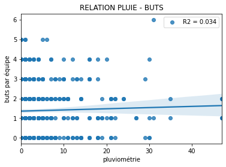

```python
slope, intercept, r_value, pv, se = stats.linregress(df_team_meteo['rainfall'],df_team_meteo['team_goal'])

sns.regplot(x="rainfall", y="team_goal", data=df_team_meteo, label=f"R2 = {r_value.round(3)}").legend(loc="best")
plt.title("RELATION PLUIE - BUTS")
plt.xlabel("pluviométrie")
plt.ylabel("buts par équipe");
```

A première vue pas de relation visible entre la pluie et les performances des équipes.

Voyons si le fait de distinguer la présence ou l'absence de pluie peut révéler des informations

### Seconde approche : création de 2 classes pour la pluviométrie (présence ou absence de pluie)

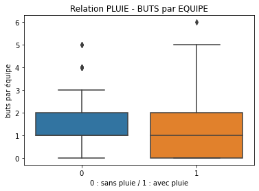

```python
plt.figure()
sns.boxplot(y="team_goal", x="rain", data=df_team_meteo)
plt.title("Relation PLUIE - BUTS par EQUIPE")
plt.xlabel("0 : sans pluie / 1 : avec pluie")
plt.ylabel("buts par équipe");
```

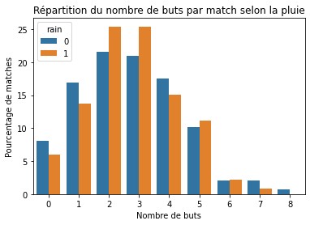

```python
# distribution du nombre de buts selon la pluie
plt.figure()
sns.barplot(x=match_pluie["team_goal"],y=match_pluie["percent_matches"], hue=match_pluie["rain"])
plt.title("Répartition du nombre de buts par match selon la pluie")
plt.xlabel("Nombre de buts")
plt.ylabel("Pourcentage de matches")
plt.show()
```

### Troisième approche : création de davantage de classes pour la pluie, et régression sur les moyennes

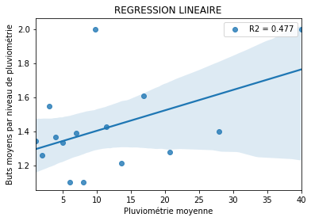

```python
from scipy import stats

slope, intercept, r_value, pv, se = stats.linregress(df_by_detailed_rain_mean['rainfall'],df_by_detailed_rain_mean['team_goal'])

sns.regplot(x="rainfall", y="team_goal", data=df_by_detailed_rain_mean, label=f"R2 = {r_value.round(3)}").legend(loc="best")
plt.title("REGRESSION LINEAIRE")
plt.ylabel("Buts moyens par niveau de pluviométrie")
plt.xlabel("Pluviométrie moyenne")
plt.show()
```

**Concernant le niveau de pluie, on retient que :**

- Lorsqu'il pleut, on constate que la dispersion du nombre de buts est plus importante (on peut s'attendre à tout)
- Quand il ne pleut pas, la proportion de matchs avec 0 ou 1 buts est légèrement plus importante
- A contrario quand il pleut, la proportion de matchs avec 2 ou 3 buts est plus importante
- Lorsqu'on crée différentes classes selon le degré de pluviométrie, on peut parvenir à des relations entre la pluviométrie moyenne et le nombre moyen de buts marqués par équipe et par match. On remarque que, plus le nombre de classes diminue (et donc plus le nombre d'observations se réduit), plus le R2 est important. Ce constat interroge sur la robustesse de la relation.

## Analyse équipes - température

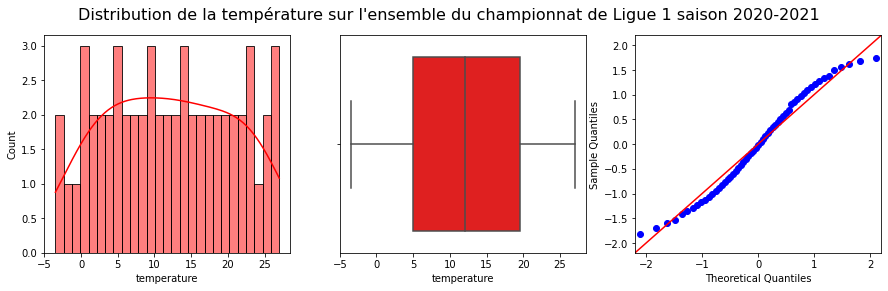

```python
df_5 = pd.read_sql_query("SELECT temperature FROM matches GROUP BY temperature", conn)

fig, ax = plt.subplots(ncols=3)
fig.set_size_inches(15, 4)

fig.suptitle('Distribution de la température sur l\'ensemble du championnat de Ligue 1 saison 2020-2021', fontsize=16)
sns.histplot(data=df_5, x="temperature", bins=27, kde=True, color = 'red', ax=ax[0])
sns.boxplot(data=df_5, x="temperature", color='red', ax=ax[1])
sm.qqplot(df_5['temperature'], stats.t, fit=True, line="45", ax=ax[2])

plt.show()
```

### Analyse de la moyenne des buts marqués selon les températures

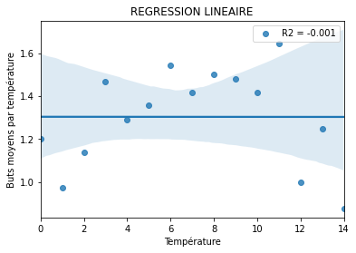

```python
from scipy import stats

slope, intercept, r_value, pv, se = stats.linregress(df_by_detailed_temp_mean['temperature_category'],df_by_detailed_temp_mean['team_goal'])

sns.regplot(x="temperature_category", y="team_goal", data=df_by_detailed_temp_mean, label=f"R2 = {r_value.round(3)}").legend(loc="best")
plt.title("REGRESSION LINEAIRE")
plt.ylabel("Buts moyens par température")
plt.xlabel("Température")
plt.show()
```

On voit clairement que, s'il semble y avoir une relation entre les deux variables (les températures et la moyenne des buts par match et par équipe), elle n'est pas linéaire mais plutôt ploynomiale de degré 2.

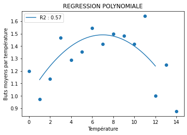

```python
import numpy
import matplotlib.pyplot as plt
from sklearn.metrics import r2_score

x = df_by_detailed_temp_mean["temperature_category"]
y = df_by_detailed_temp_mean["team_goal"]

poly_reg = numpy.poly1d(numpy.polyfit(x, y, 2))

r2 = r2_score(y, poly_reg(x))
myline = numpy.linspace(1, 12, 100)

plt.scatter(x, y)
plt.plot(myline, poly_reg(myline))
plt.legend([f"R2 : {np.round(r2,2)}"])
plt.title("REGRESSION POLYNOMIALE")
plt.ylabel("Buts moyens par température")
plt.xlabel("Température")
plt.show()
```

```python
import statsmodels.formula.api as smf

results = smf.ols('team_goal ~ temperature_category + I(temperature_category**2)', data=df_by_detailed_temp_mean).fit()

print(results.summary())
```

```
                            OLS Regression Results
==============================================================================
Dep. Variable:              team_goal   R-squared:                       0.570
Model:                            OLS   Adj. R-squared:                  0.498
Method:                 Least Squares   F-statistic:                     7.949
Date:                Wed, 28 Jul 2021   Prob (F-statistic):            0.00633
Time:                        09:30:49   Log-Likelihood:                 7.7685
No. Observations:                  15   AIC:                            -9.537
Df Residuals:                      12   BIC:                            -7.413
Df Model:                           2
Covariance Type:            nonrobust
================================================================================================
                                   coef    std err          t      P>|t|      [0.025      0.975]
------------------------------------------------------------------------------------------------
Intercept                        1.0002      0.110      9.104      0.000       0.761       1.240
temperature_category             0.1400      0.036      3.844      0.002       0.061       0.219
I(temperature_category ** 2)    -0.0100      0.003     -3.987      0.002      -0.015      -0.005
==============================================================================
Omnibus:                        0.807   Durbin-Watson:                   2.840
Prob(Omnibus):                  0.668   Jarque-Bera (JB):                0.646
Skew:                           0.447   Prob(JB):                        0.724
Kurtosis:                       2.517   Cond. No.                         254.
==============================================================================

Notes:
[1] Standard Errors assume that the covariance matrix of the errors is correctly specified.
```

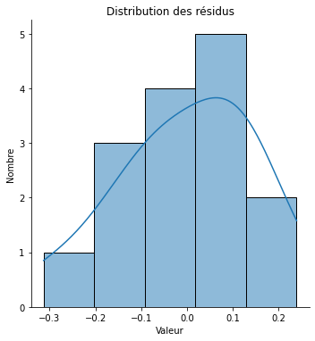

```python
# Calcul des résidus
y_hat = results.predict(df_by_detailed_temp_mean[["team_goal","temperature_category"]]) # on calcule les y prédits
residus = y_hat - df_by_detailed_temp_mean["team_goal"] # les résidus : différence entre la valeur déterminée par le modèle et la vraie valeur
# Distribution des résidus (histogramme)
sns.displot(data=residus, kde=True);
plt.title("Distribution des résidus")
plt.ylabel("Nombre")
plt.xlabel("Valeur")
plt.show()
```

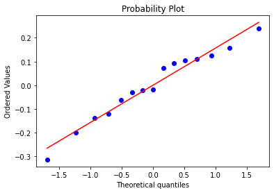

```python
# Distribution des résidus (qqplot)
import pylab
import scipy.stats as stats

stats.probplot(residus, dist="norm", plot=pylab)
pylab.show()
```

### Analyse de la moyenne des buts marqués selon les températures, en fonction des équipes

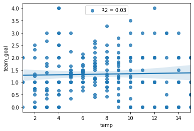

```python
from scipy import stats

slope, intercept, r_value, pv, se = stats.linregress(df['temp'],df['team_goal'])

sns.regplot(x="temp", y="team_goal", data=df, label=f"R2 = {r_value.round(3)}").legend(loc="best")
```

**Conclusion** : Lien température - buts : pas de lien quand on cumule le détail des équipes, que ce soit en régression linéaire (R2=0.03) ou du second degré (R2 de 0.02)

**Etape suivante** : Lorsqu'on se penche sur les relations par équipes, on observe des relations de nature différente selon les villes (relation linéaire positive, négative, absence de relation). Les régressions réalisées sur chacune des équipes ne font apparaitre aucune relation robuste, hormis pour l'équipe de Saint-Etienne (relation linéaire positive avec un R2 de 0.76).

# Etude des relations météo - joueurs

## Relation players - pluie

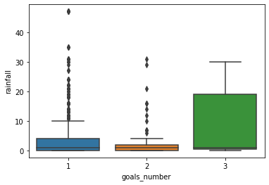

```python
plt.figure()
sns.boxplot(x="goals_number", y="rainfall", data=df_player2_meteo)
```

Le nombre maximum de buts marqués par match pour 1 joueur est 3. On note une forte disparité des valeurs de cette modalité (886, 81, 7). Il est nécessaire de faire des classes pour rééquilibrer

## Relation players - température

### Nombre buts marqués par joueur par match (par temp)

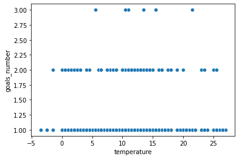

```python
# Relation entre la température et le nombre de buts marqués par joueur par match
# on constate que le nombre de buts maximum par joueur semble augmenter quand la température est tempérée

plt.figure()
sns.scatterplot(x="temperature", y="goals_number", data=df_player2_meteo);
```

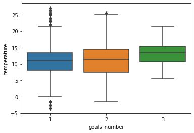

```python
# Distribution du nombre de buts marqués par joueur par match
# On constate que les quantiles autour de la médiane se situent pour les 3 distributions entre 5 et 15°C.

plt.figure()
sns.boxplot(x="goals_number", y="temperature", data=df_player2_meteo);
```

### Nombre buts moyen marqués par joueur et par match (par temp)

A priori, la température n'a que peu d'incidence sur le nombre moyen de buts marqués par joueur. Le résultat R2 ci-dessous le confirme.

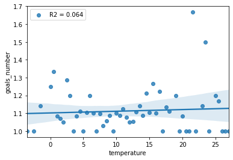

```python
from scipy import stats

slope, intercept, r_value, pv, se = stats.linregress(goals_players_temp_index_free['temperature'],goals_players_temp_index_free['goals_number'])
sns.regplot(data = goals_players_temp_index_free, x='temperature', y="goals_number", label=f"R2 = {r_value.round(3)}").legend(loc="best");
```

### Nombre total de buts par joueur par classe de température intervalle de 2

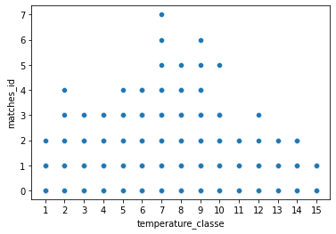

```python
sns.scatterplot(data = goals_player_by_temp_index, x='temperature_classe', y="matches_id");
```

### Nombre moyen de buts marqués par match par intervalle de température de 2

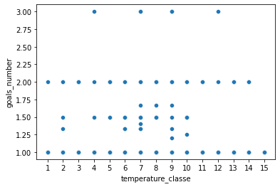

```python
sns.scatterplot(data = goals_player_mean_by_temp, x='temperature_classe', y="goals_number");
```

### Nombre moyen de buts marqués par intervalle de température de 2

[figure not shown]

```python
sns.scatterplot(data = goals_player_mean_by_temp_2, x='temperature_classe', y="matches_id");
```

# Prolongements et améliorations :

- Poursuivre le travail sur les classes de températures, avec 3 intervalles (froid, tempéré, chaud)
- Analyse temporelle à réaliser pour identifier des schémas (hypothèse sous-jecente : fatigue accrue des joueurs en fin de saison, manque d'entrainement en début de saison). Nécessité de travailler sur plusieurs années pour être fiable.
- Accroitre le champ de l'étude pour confirmer la relation avec la température en allant chercher les données des années précédentes
- Affiner les données en termes de météo (plus de données, précision plus fine au niveau des horaires)
- Elargir le champ de recherche des facteurs pouvant expliquer le dynamisme d'un match